# Soile’s spruce seasonal wood series winter genes analysis

Nicolas Delhomme

2017-10-03

# 1 Setup

# 2 Environment

Set the working dir

```r
setwd("/mnt/picea/projects/spruce/htuominen/27_SpruceTimeSeries")
```

Libraries

```r
suppressPackageStartupMessages(library(LSD))
suppressPackageStartupMessages(library(pander))
suppressPackageStartupMessages(library(RColorBrewer))
suppressPackageStartupMessages(library(VennDiagram))
```

source

```r
source("~/Git/UPSCb/src/R/expressionSpecificityUtility.R")
source("~/Git/UPSCb/src/R/plot.multidensity.R")
```

plotting param

```r
mar <- par("mar")
pal <- brewer.pal(8,"Dark2")
```

Read the data

```r
load("analysis/HTSeq/20161216/library-size-normalized_variance-stabilized_data.rda")
```

Read the doc

```r
samples <- read.csv("~/Git/UPSCb/projects/spruce-wood-time-series/doc/samplesmod.csv",row.names=1)
```

Read the list of winter only highly expressed genes

```r
wg <- scan("analysis/season/high-expression-winter-genes",what="character")
```

Order the Date factor by date and not alphabetically

```r
dates <- rev(unique(as.character(samples$Date)))
dates <- dates[c(3:23,1,2)]
for(r in dates){
  samples$Date <- relevel(samples$Date,r)
}
```

# 3 Process

```r
stopifnot(all(colnames(vst.mod) == rownames(samples)))
phloem.mat <- vst.mod[phloem,samples$Tissue=="Phloem"]

xylem.mat <- vst.mod[xylem,samples$Tissue=="Xylem"]
```

## 3.1 Phloem

### 3.1.1 Cluster

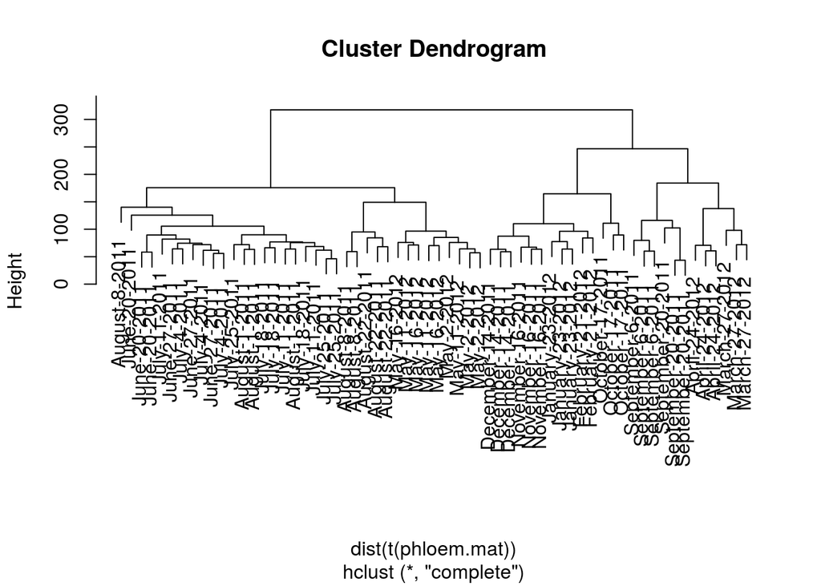

```r
phloem.hc <- hclust(dist(t(phloem.mat)))
phloem.ct <- cutree(phloem.hc,5)
plot(phloem.hc,labels = samples[phloem.hc$labels,"Date"])
```

### 3.1.2 Expression specificity

Split by season

```r
split(samples[phloem.hc$labels,"Date"],phloem.ct)
```

```
## $`1`
##  [1] June-20-2011  June-20-2011  June-20-2011  June-27-2011  June-27-2011
##  [6] June-27-2011  July-4-2011   July-4-2011   July-4-2011   July-11-2011
## [11] July-11-2011  July-11-2011  July-18-2011  July-18-2011  July-18-2011
## [16] July-25-2011  July-25-2011  July-25-2011  August-1-2011 August-1-2011
## [21] August-1-2011 August-8-2011
## 23 Levels: June-7-2011 June-13-2011 June-20-2011 ... May-16-2012
##
## $`2`
##  [1] August-8-2011  August-8-2011  August-22-2011 August-22-2011
##  [5] August-22-2011 May-2-2012     May-2-2012     May-2-2012
##  [9] May-11-2012    May-11-2012    May-11-2012    May-16-2012
## [13] May-16-2012    May-16-2012
## 23 Levels: June-7-2011 June-13-2011 June-20-2011 ... May-16-2012
##
```

[output cut: 16 more lines]

```r
phloem.tp <- factor(phloem.ct,labels=c("Summer","Summer-early-late","Autumn","Winter","Spring"))
phloem.es <- expressionSpecificity(phloem.mat,as.character(phloem.tp),mode = "local",output="complete")
```

```
## Calculating tissue specificity
```

The genes are very ubiquitous

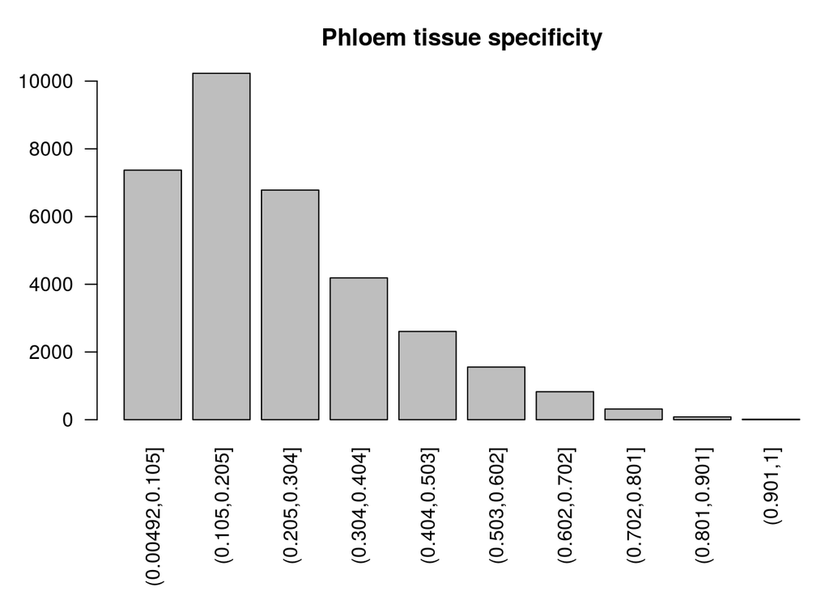

```r
par(mar=c(7.1,4.1,3.1,0.1))
barplot(table(cut(phloem.es[,"score"],10)),las=2,main="Phloem tissue specificity")
```

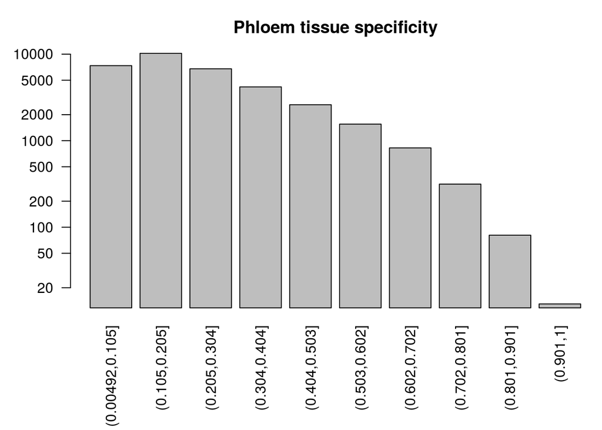

```r
barplot(table(cut(phloem.es[,"score"],10)),las=2,main="Phloem tissue specificity",log="y")
```

Interestingly the more expressed genes are the most ubiquitous

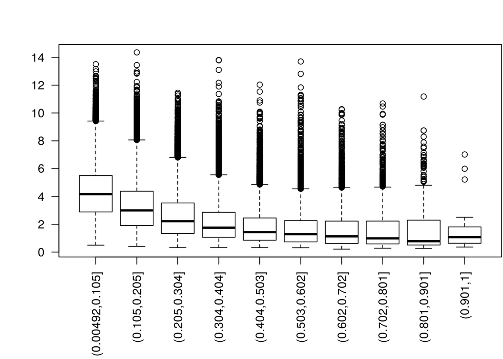

```r
par(mar=c(7.1,4.1,3.1,0.1))
boxplot(split(phloem.es[,2:6],cut(phloem.es[,"score"],10)),las=2)
```

How many genes are not expressed across a season

```r
pander(round(colSums(is.na(phloem.es[,2:6])) / nrow(phloem.es) * 100,2))
```

| Autumn | Spring | Summer | Summer-early-late | Winter |
| --- | --- | --- | --- | --- |
| 1.25 | 1.42 | 0.29 | 0.18 | 1.98 |

How expressed are the NA containing genes (max expression)

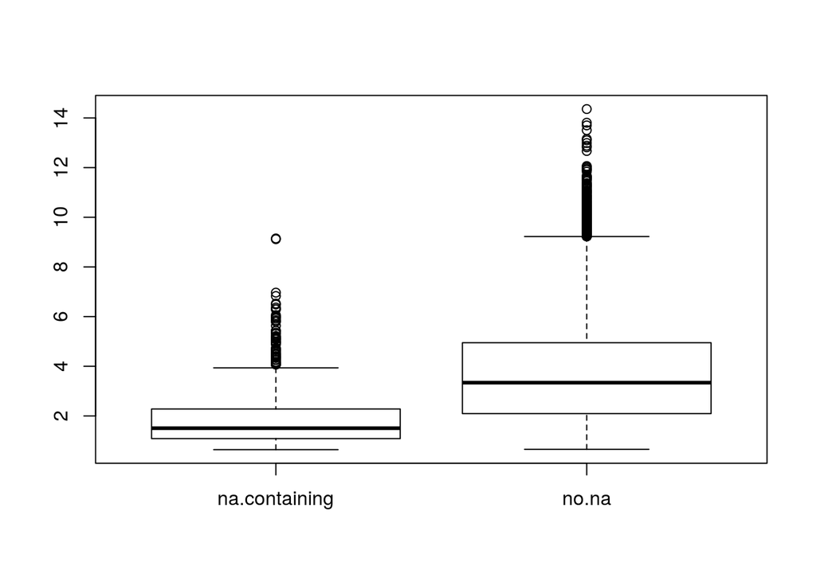

```r
boxplot(list(na.containing=phloem.es[rowSums(is.na(phloem.es[,2:6]))>=1,"maxn"],
             no.na=phloem.es[rowSums(is.na(phloem.es[,2:6]))==0,"maxn"]))
```

Obviously the expression levels is inversely proportional to the number of NAs

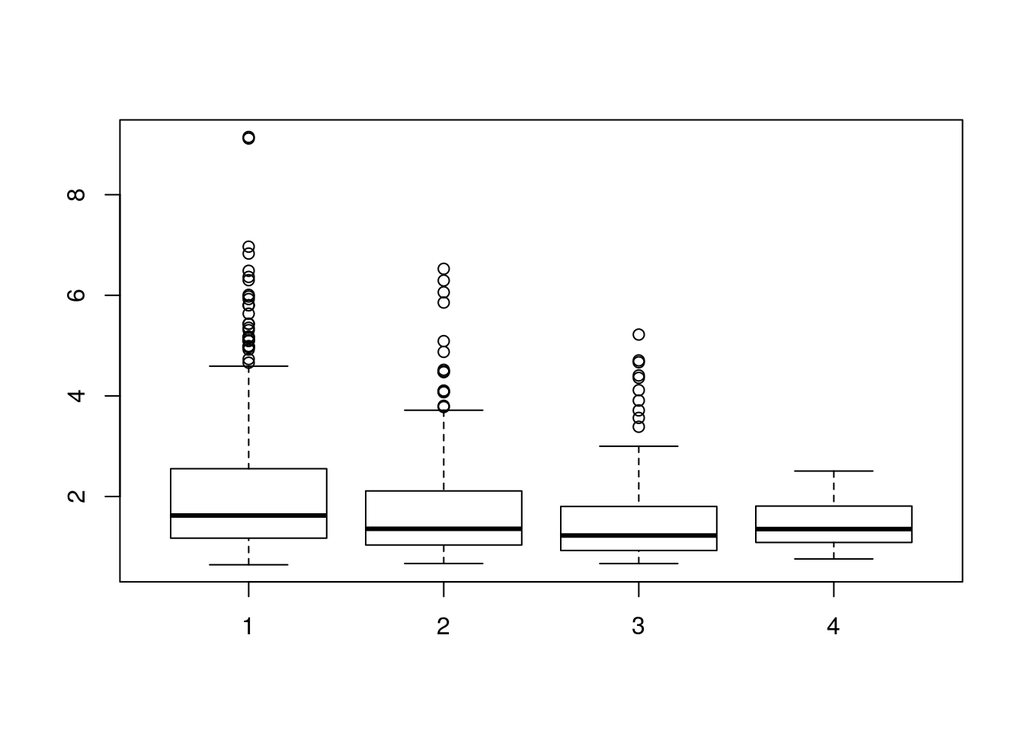

```r
boxplot(split(phloem.es[rowSums(is.na(phloem.es[,2:6]))>=1,"maxn"],
              rowSums(is.na(phloem.es[,2:6]))[rowSums(is.na(phloem.es[,2:6]))>=1]))
```

Check for winter specific genes

```
## There are 10040 genes with an expression peak in Summer
```

```
## There are 2948 genes with an expression peak in Summer-early-late
```

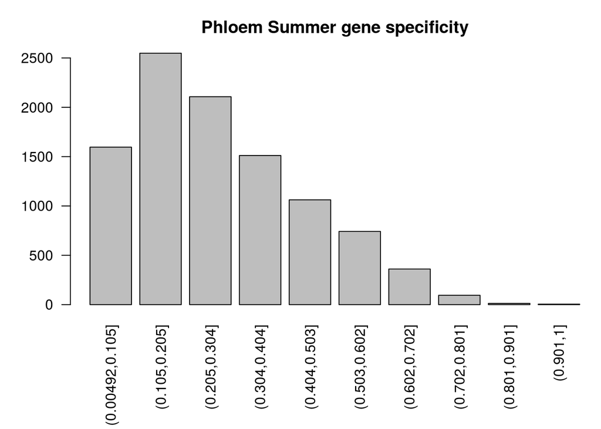

```
## There are 5233 genes with an expression peak in Autumn
```

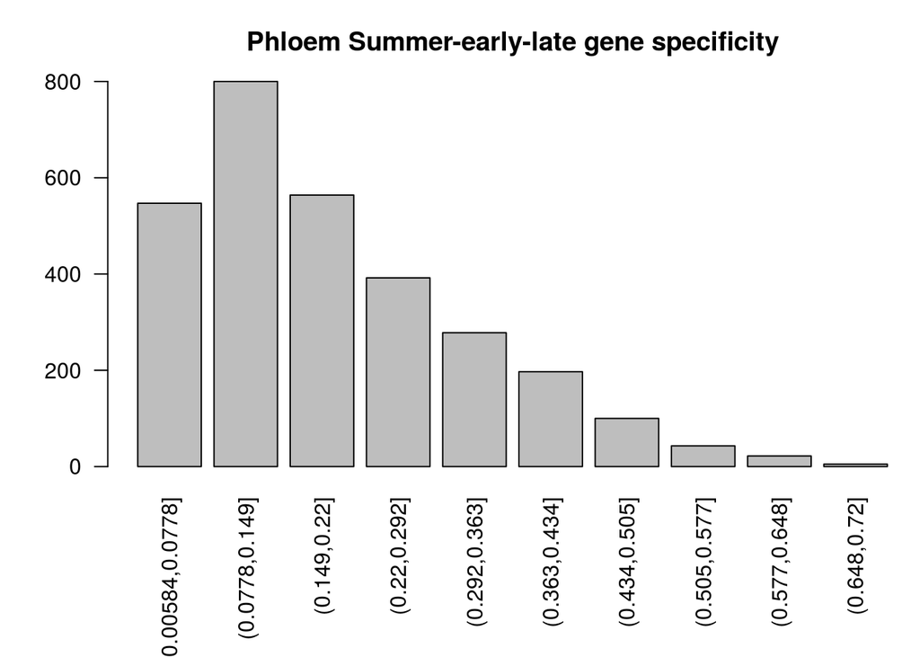

```
## There are 9462 genes with an expression peak in Winter
```

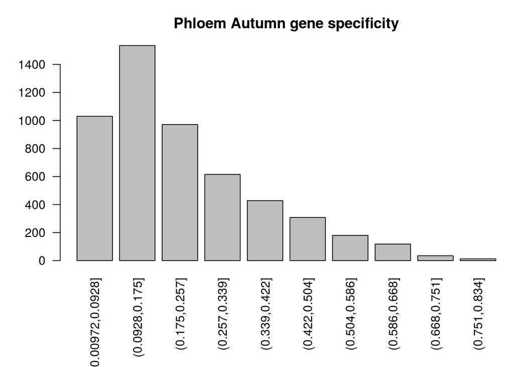

```
## There are 6283 genes with an expression peak in Spring
```

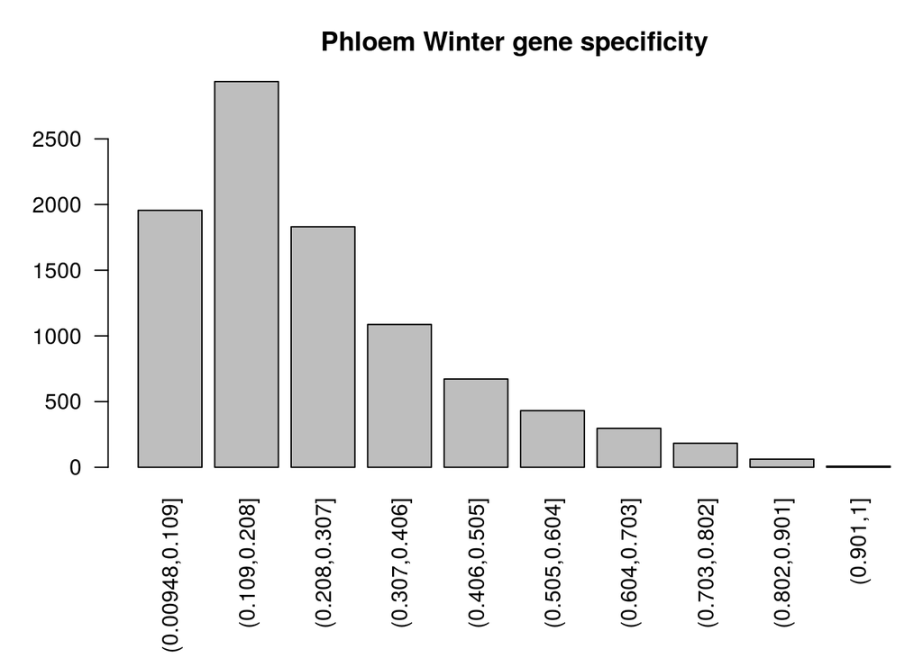

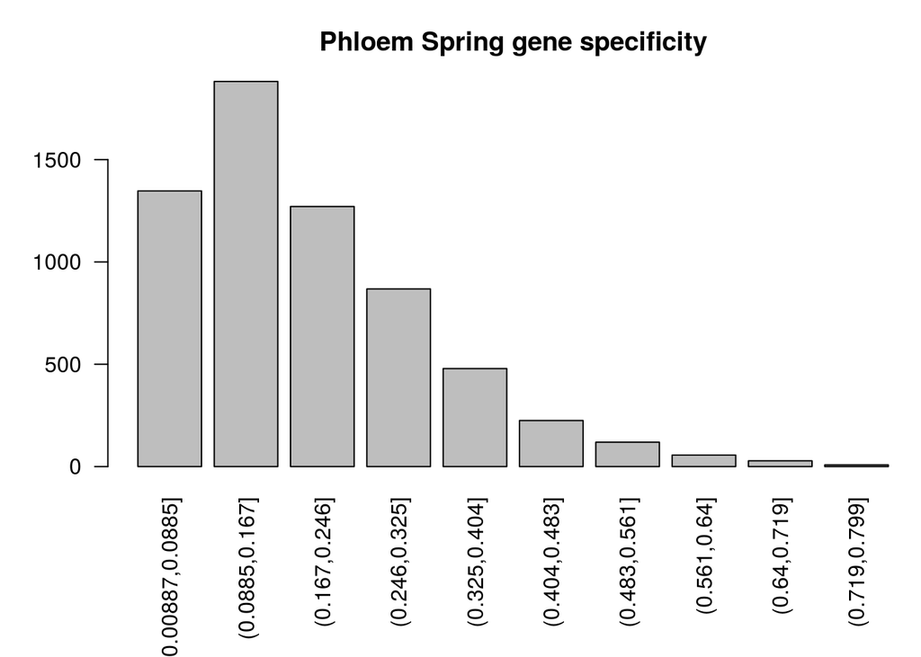

```r
dev.null <- sapply(levels(phloem.tp),function(tp){
  sel <- phloem.es[,tp] == phloem.es[,"maxn"]
  message(sprintf("There are %s genes with an expression peak in %s",
                  sum(sel,na.rm=TRUE),tp))
  par(mar=c(7.1,4.1,3.1,0.1))
  barplot(table(cut(phloem.es[sel,"score"],10)),las=2,
          main=paste0("Phloem ",tp," gene specificity"))
})
```

```r
w.genes <- phloem.es[phloem.es[,"Winter"] == phloem.es[,"maxn"] & !is.na(phloem.es[,"Winter"]),]
w.genes <- cbind(w.genes,lfc=w.genes[,"Winter"] - apply(w.genes[,c(2:5)],1,max))
```

Most of the genes identified as being only highly expressed in winter are present among the phloem winter specific genes

```r
table(wg %in% rownames(w.genes))
```

```
##
## FALSE  TRUE
##    23   455
```

```r
p.wg <- wg[wg %in% rownames(w.genes)]
```

Plot the expression change vs. the expression specificity The winter highly expressed genes are distributed all over.

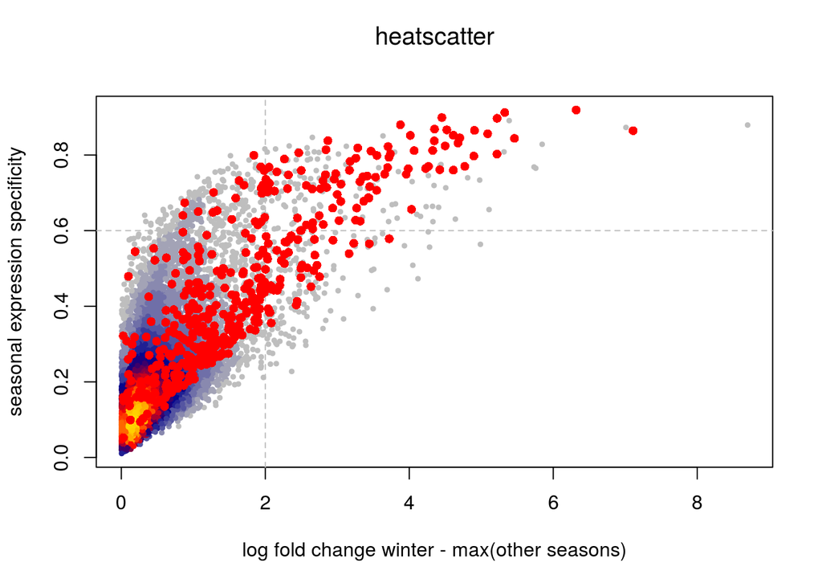

```r
heatscatter(w.genes[,"lfc"],w.genes[,"score"],
            ylab="seasonal expression specificity",xlab="log fold change winter - max(other seasons)")
abline(v=2,lty=2,col="gray")
abline(h=0.6,lty=2,col="gray")
points(w.genes[p.wg,"lfc"],w.genes[p.wg,"score"],col=2,pch=16)
```

the lfc can only be positive since these genes are most highly expressed in winter

```r
phloem.winter.genes <- names(which(w.genes[,"score"]>0.6 & w.genes[,"lfc"]>=2))

message(sprintf("There are %s phloem genes that are winter specific",length(phloem.winter.genes)))
```

```
## There are 207 phloem genes that are winter specific
```

```r
dir.create(file.path("analysis","season"),showWarnings = FALSE)
write(phloem.winter.genes,file = "analysis/season/phloem.winter.genes")
```

## 3.2 Xylem

### 3.2.1 Cluster

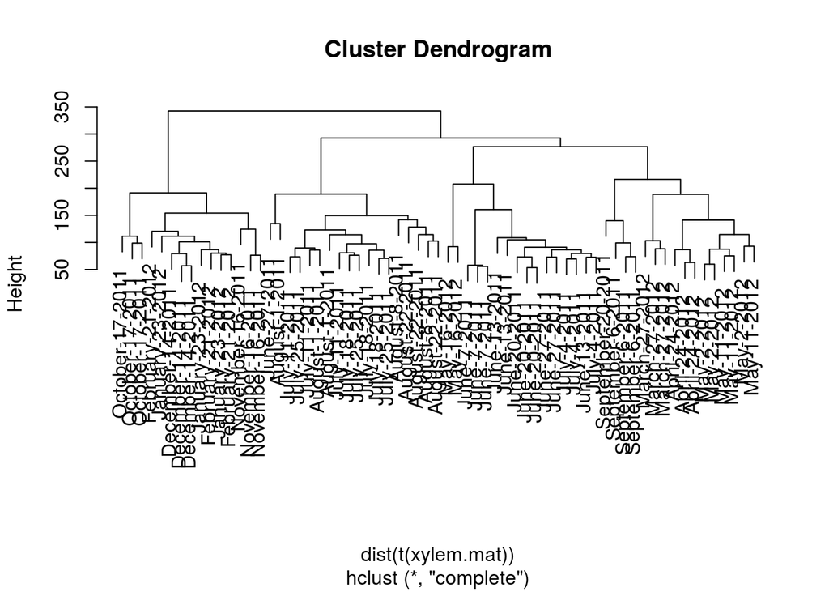

```r
xylem.hc <- hclust(dist(t(xylem.mat)))
xylem.ct <- cutree(xylem.hc,5)
plot(xylem.hc,labels = samples[xylem.hc$labels,"Date"])
```

### 3.2.2 Expression specificity

Split by season

```r
split(samples[xylem.hc$labels,"Date"],xylem.ct)
```

```
## $`1`
##  [1] June-7-2011  June-7-2011  June-7-2011  June-13-2011 June-13-2011
##  [6] June-13-2011 June-20-2011 June-20-2011 June-20-2011 June-27-2011
## [11] June-27-2011 July-4-2011  July-4-2011  July-4-2011  May-16-2012
## [16] May-16-2012
## 23 Levels: June-7-2011 June-13-2011 June-20-2011 ... May-16-2012
##
## $`2`
##  [1] June-27-2011   July-11-2011   July-11-2011   July-11-2011
##  [5] July-18-2011   July-18-2011   July-18-2011   July-25-2011
##  [9] July-25-2011   July-25-2011   August-1-2011  August-1-2011
## [13] August-1-2011  August-8-2011  August-8-2011  August-22-2011
## [17] August-22-2011 August-22-2011
## 23 Levels: June-7-2011 June-13-2011 June-20-2011 ... May-16-2012
##
```

[output cut: 16 more lines]

```r
xylem.tp <- factor(xylem.ct,labels=c("Summer-early","Summer-late","Autumn","Winter","Spring"))
xylem.es <- expressionSpecificity(xylem.mat,as.character(xylem.tp),mode = "local",output="complete")
```

```
## Calculating tissue specificity
```

The genes are very ubiquitous

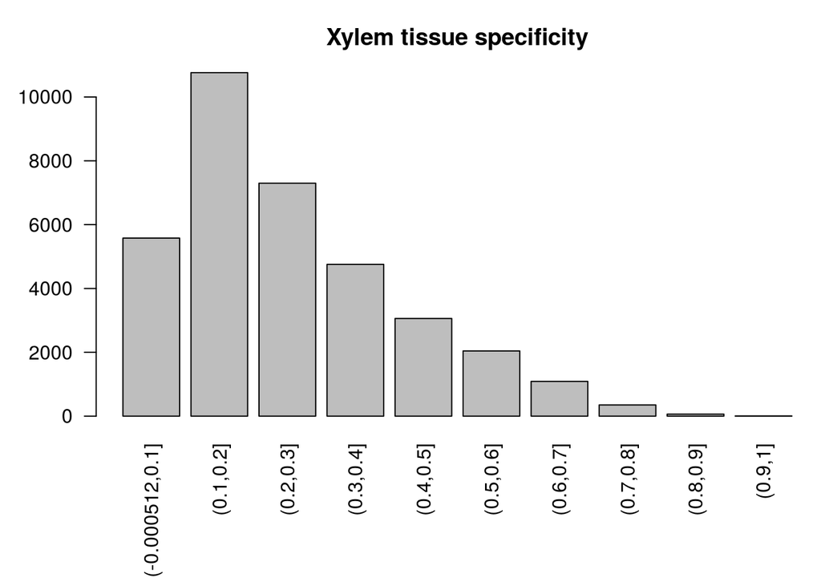

```r
par(mar=c(7.1,4.1,3.1,0.1))
barplot(table(cut(xylem.es[,"score"],10)),las=2,main="Xylem tissue specificity")
```

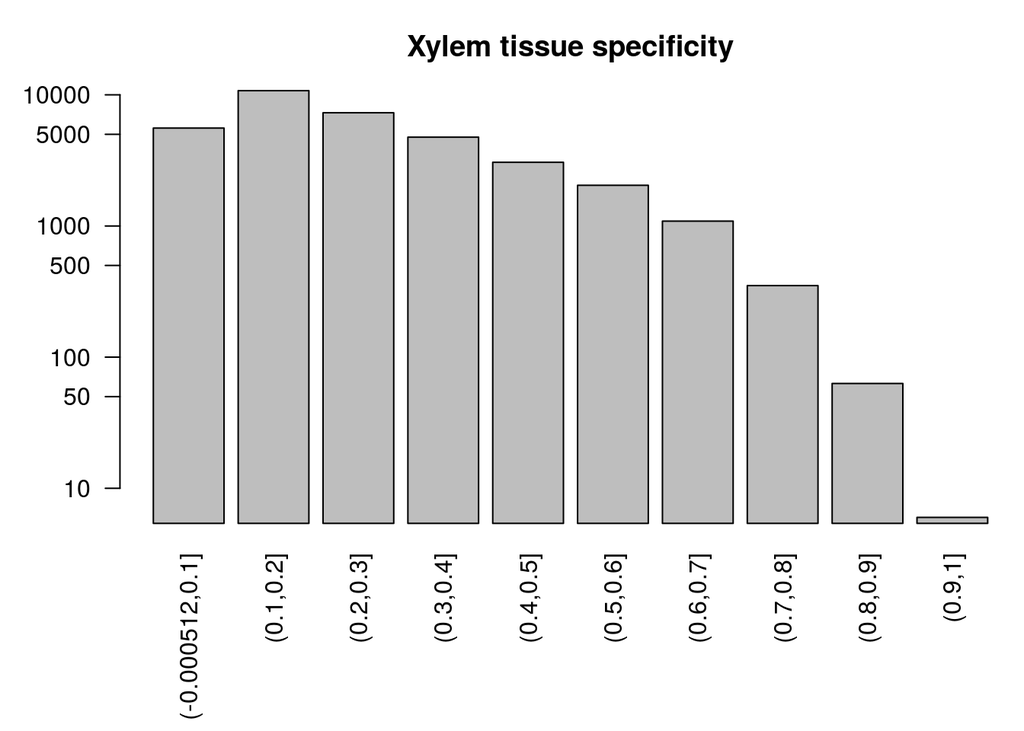

```r
barplot(table(cut(xylem.es[,"score"],10)),las=2,main="Xylem tissue specificity",log="y")
```

Interestingly the more expressed genes are the most ubiquitous

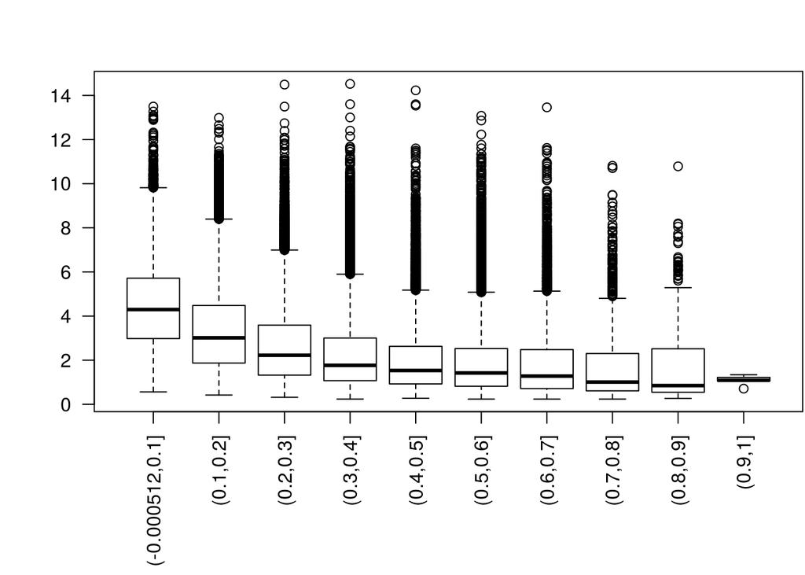

```r
par(mar=c(7.1,4.1,3.1,0.1))
boxplot(split(xylem.es[,2:6],cut(xylem.es[,"score"],10)),las=2)
```

How many genes are not expressed across a season

```r
pander(round(colSums(is.na(xylem.es[,2:6])) / nrow(xylem.es) * 100,2))
```

| Autumn | Spring | Summer-early | Summer-late | Winter |
| --- | --- | --- | --- | --- |
| 1.8 | 1.19 | 0.47 | 0.43 | 2.59 |

How expressed are the NA containing genes (max expression)

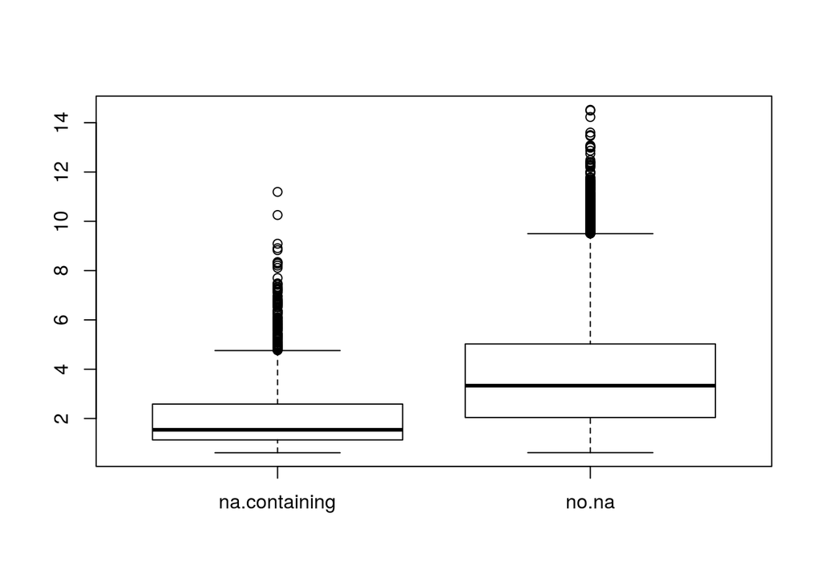

```r
boxplot(list(na.containing=xylem.es[rowSums(is.na(xylem.es[,2:6]))>=1,"maxn"],
             no.na=xylem.es[rowSums(is.na(xylem.es[,2:6]))==0,"maxn"]))
```

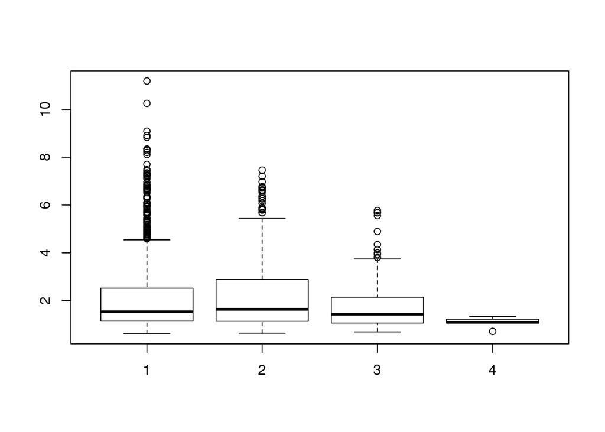

```r
boxplot(split(xylem.es[rowSums(is.na(xylem.es[,2:6]))>=1,"maxn"],
              rowSums(is.na(xylem.es[,2:6]))[rowSums(is.na(xylem.es[,2:6]))>=1]))
```

Check for winter specific genes

```
## There are 7670 genes with an expression peak in Summer-early
```

```
## There are 6394 genes with an expression peak in Summer-late
```

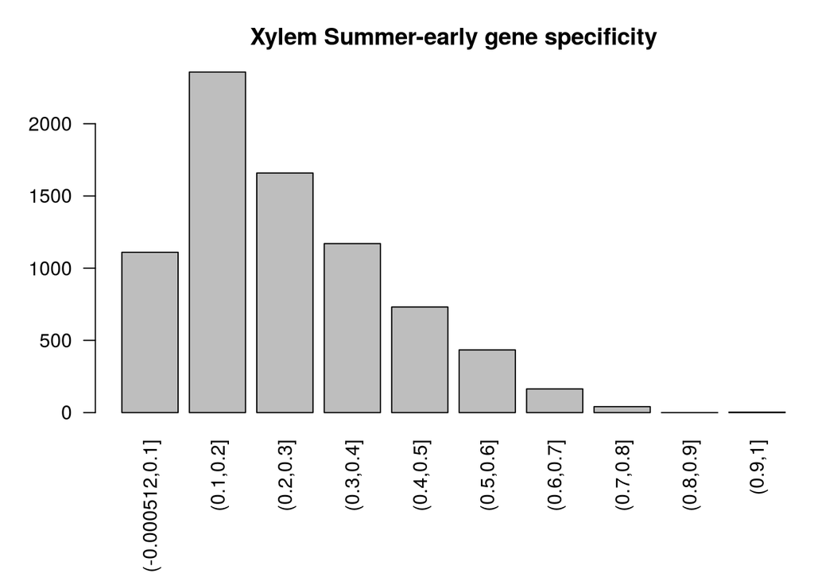

```
## There are 5644 genes with an expression peak in Autumn
```

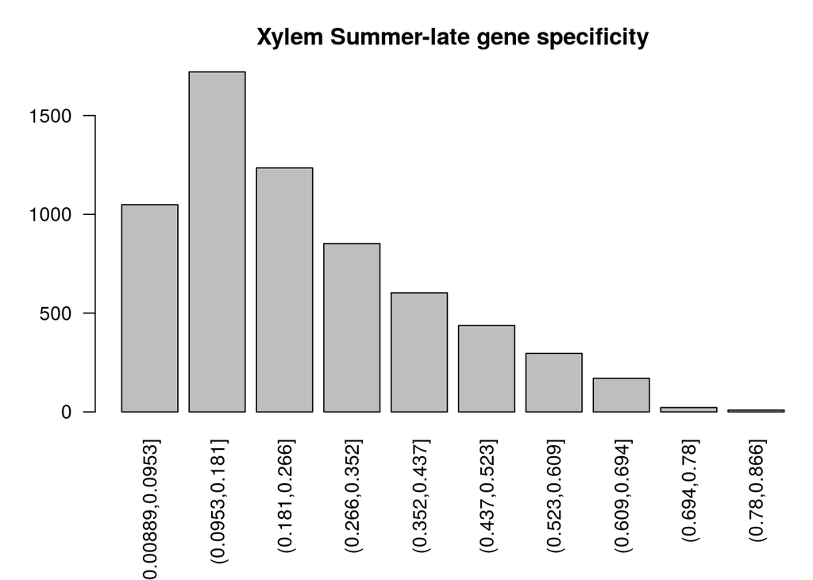

```
## There are 9546 genes with an expression peak in Winter
```

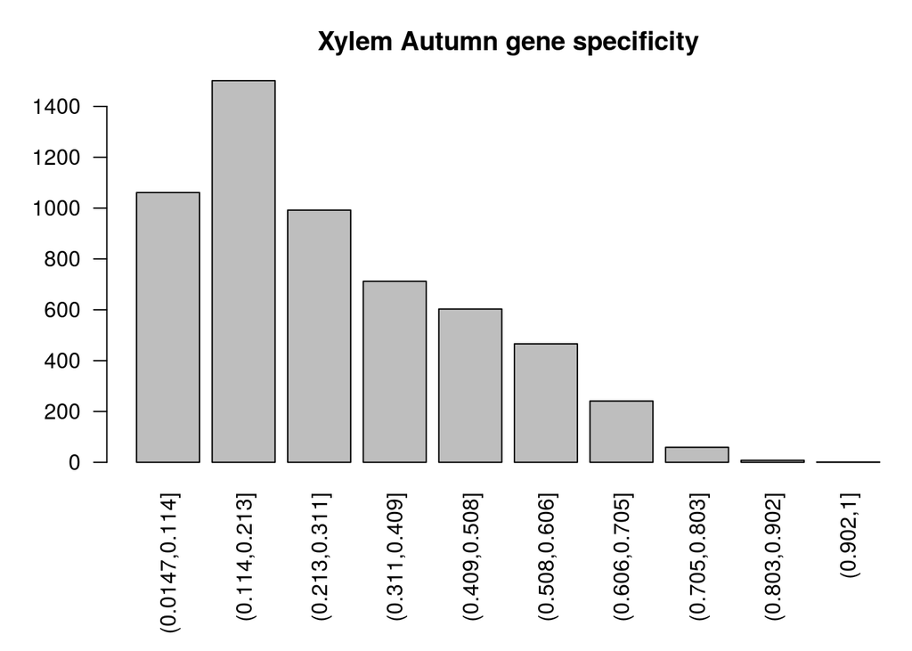

```
## There are 5753 genes with an expression peak in Spring
```

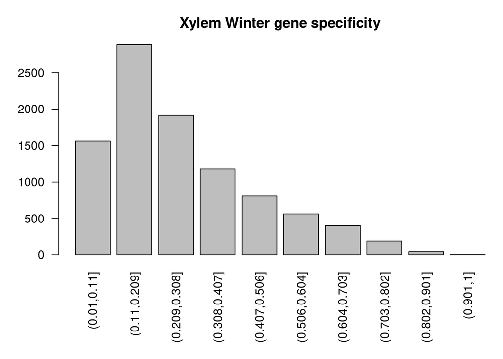

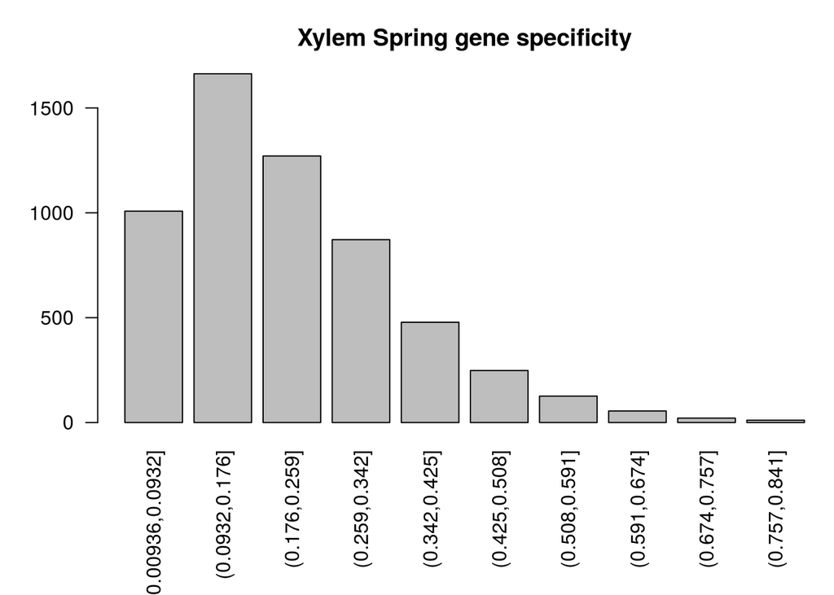

```r
dev.null <- sapply(levels(xylem.tp),function(tp){
  sel <- xylem.es[,tp] == xylem.es[,"maxn"]
  message(sprintf("There are %s genes with an expression peak in %s",
                  sum(sel,na.rm=TRUE),tp))
  par(mar=c(7.1,4.1,3.1,0.1))
  barplot(table(cut(xylem.es[sel,"score"],10)),las=2,
          main=paste0("Xylem ",tp," gene specificity"))
})
```

```r
xw.genes <- xylem.es[xylem.es[,"Winter"] == xylem.es[,"maxn"] & !is.na(xylem.es[,"Winter"]),]
xw.genes <- cbind(xw.genes,lfc=xw.genes[,"Winter"] - apply(xw.genes[,c(2:5)],1,max))
```

```r
table(wg %in% rownames(xw.genes))
```

```
##
## FALSE  TRUE
##    33   445
```

```r
x.wg <- wg[wg %in% rownames(xw.genes)]
```

Plot the expression change vs. the expression specificity The winter highly expressed genes are distributed all over.

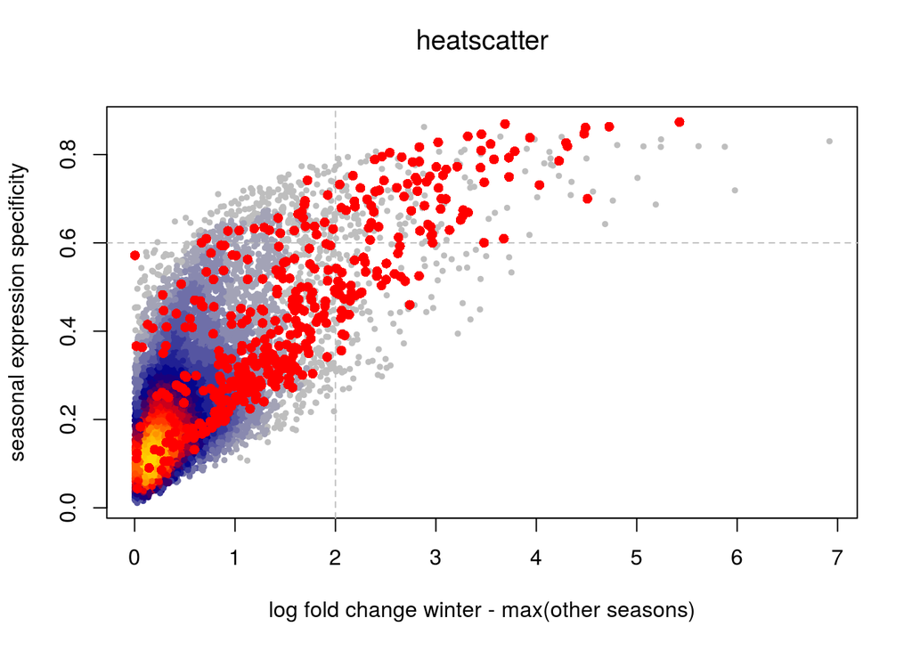

```r
heatscatter(xw.genes[,"lfc"],xw.genes[,"score"],
            ylab="seasonal expression specificity",xlab="log fold change winter - max(other seasons)")
abline(v=2,lty=2,col="gray")
abline(h=0.6,lty=2,col="gray")
points(xw.genes[x.wg,"lfc"],xw.genes[x.wg,"score"],col=2,pch=16)
```

the lfc can only be positive since these genes are most highly expressed in winter

```r
xylem.winter.genes <- names(which(xw.genes[,"score"]>0.6 & xw.genes[,"lfc"]>=2))
message(sprintf("There are %s xylem genes that are winter specific",length(xylem.winter.genes)))
```

```
## There are 217 xylem genes that are winter specific
```

```r
write(xylem.winter.genes,file = "analysis/season/xylem.winter.genes")
```

## 3.3 Overlap

Tissue specific

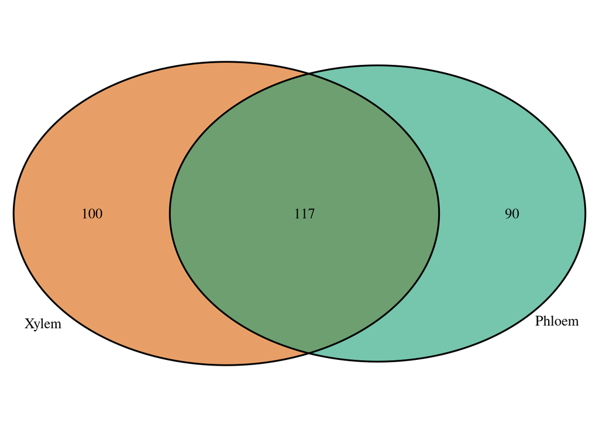

```r
plot.new()
grid.draw(venn.diagram(list(Phloem=phloem.winter.genes,
                            Xylem=xylem.winter.genes),
                       filename = NULL,fill=pal[1:2],alpha=0.6))
```

```r
table(union(p.wg,x.wg) %in% wg)
```

```
##
## TRUE
##  470
```

The overlap

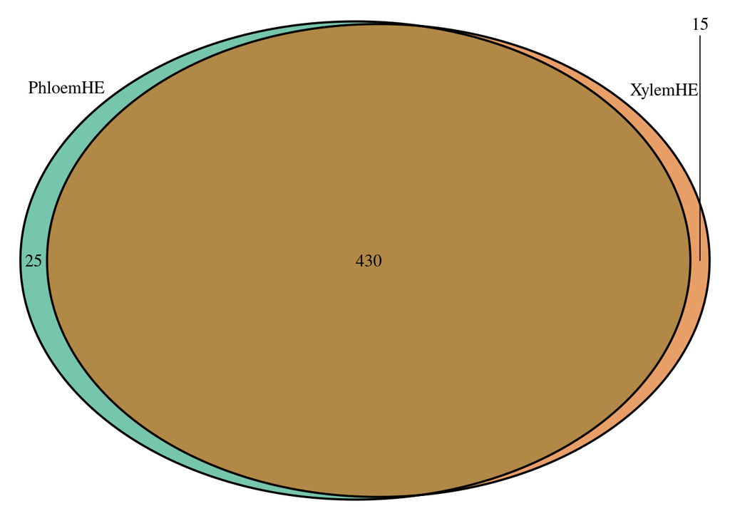

```r
plot.new()
grid.draw(venn.diagram(list(PhloemHE=p.wg,
                            XylemHE=x.wg),
                       filename = NULL,fill=pal[1:2],alpha=0.6))
```

### 3.3.1 Phloem specific

```r
write(setdiff(phloem.winter.genes,xylem.winter.genes),file="analysis/season/phloem-only.winter.genes")
```

### 3.3.2 Xylem specific

```r
write(setdiff(xylem.winter.genes,phloem.winter.genes),file="analysis/season/xylem-only.winter.genes")
```

### 3.3.3 Common

```r
write(intersect(phloem.winter.genes,xylem.winter.genes),file="analysis/season/phloem-xylem.winter.genes")
```